# Practical 4 - Visualising data

Analysing data

## Today

- Basic descriptive visualisation
- What makes a good plot
- Including plots in papers/reports
- Write-up: materials

## Guided part

First of all, let’s make sure we’re all set up:

- Log into Canvas and go to this week’s practical
- Download the “prac_04_visual.Rmd” file into your analysing_data project folder
- Open RStudio

### Read-in and clean

We can use code from last practical to read in and clean our data. Note that the code below is a condensed version of what we did last week but it does the same job.

```r
library(tidyverse)
theme_set(theme_grey())
# read in
gensex <- read_csv("https://mivalek.github.io/adata/gen_sex_q.csv")


### AGE

# recode age and gender
gensex <- gensex %>%
  mutate(Age = recode(Age, "18 years" = "18", "19 years old" = "19"),
         Age = as.numeric(Age),
         Gender = factor(Gender))

# count how many cases you're about to remove
age_removed <- gensex %>% filter(Age > 99) %>% nrow()

# count how many you're about to remove
all_missing <- gensex %>% filter(rowSums(is.na(gensex)) > 10) %>% nrow()

# remove them
gensex <- gensex %>% filter(Age < 100 & rowSums(is.na(gensex)) < 11)


# DESCRIPTIVES ------------------------------------------------------------

# desc for Age

age_desc <- gensex %>%
  summarise(mean = mean(Age, na.rm = T),
            sd = sd(Age, na.rm = T),
            min = min(Age, na.rm = T),
            max = max(Age, na.rm = T)) %>%
  modify(round, 2)

# Break-down of gender with age stats
gen_age_desc <- gensex %>%
  mutate(Gender = fct_explicit_na(Gender)) %>%
  group_by(Gender) %>%
  summarise(n = n(),
            perc = n()/nrow(gensex) * 100,
            mean_age = mean(Age, na.rm = T),
            sd_age = sd(Age, na.rm = T))


# # give column names (with markdown)
# # give table a caption
# # round to 2 decimal places
# gen_age_desc %>%
#   mutate(Gender = str_to_sentence(Gender)) %>%
#   kable(col.names = c("Gender", "*N*", "%", "*M*~age~", "*SD*~age~"),
#         caption = "Table 1 *Descriptive statistics by Gender*",
#         digits = 2) %>%
#   kable_styling()
```

### Visualisation

While some descriptive statistics and results are best summarised in a table, it is often worth visualising your data using plots. Some plots are great for presenting results to your audience while others are just a tool for you to get a better feel for your data and results. It is neither necessary nor desirable to include every plot you create in your write-up/paper/poster. Only show plots if they add anything of explanatory value to your body text and tables, the rest are for your eyes only (or for the appendix/supplementary materials).

Let’s look at a simple histogram of our `Age` variable:

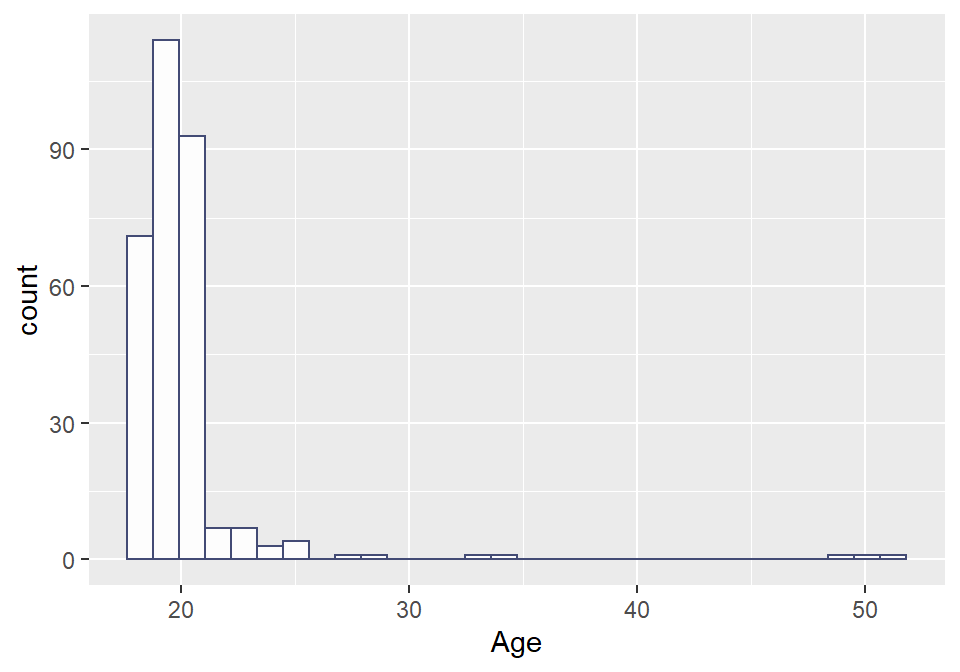

```r
gensex %>%
  ggplot(aes(x = Age)) +
  geom_histogram()
`stat_bin()` using `bins = 30`. Pick better value with `binwidth`.
```

```r
gensex %>% summary()
    Duration            Age           Gender    Gender_comfortable_1 Gender_masc_1
 Min.   :   48.0   Min.   :18.00   Female:250   Min.   :3.000        Min.   :1.000
 1st Qu.:  108.0   1st Qu.:19.00   Male  : 48   1st Qu.:9.000        1st Qu.:2.000
 Median :  149.5   Median :19.00   Other :  5   Median :9.000        Median :3.000
 Mean   :  517.8   Mean   :19.89   NA's  :  3   Mean   :8.699        Mean   :3.716
 3rd Qu.:  213.8   3rd Qu.:20.00                3rd Qu.:9.000        3rd Qu.:5.000
 Max.   :67632.0   Max.   :51.00                Max.   :9.000        Max.   :9.000

  Gender_fem_1   Gender_stability_1 Sexual_strength_1 Sexual_fewq_1   Sexual_gender_1
 Min.   :1.000   Min.   :1.000      Min.   :1.000     Min.   :1.000   Min.   :1.00
 1st Qu.:6.000   1st Qu.:8.000      1st Qu.:7.000     1st Qu.:5.000   1st Qu.:5.00
 Median :7.000   Median :9.000      Median :8.000     Median :6.000   Median :8.00
 Mean   :6.405   Mean   :8.125      Mean   :7.526     Mean   :6.154   Mean   :6.64
 3rd Qu.:8.000   3rd Qu.:9.000      3rd Qu.:9.000     3rd Qu.:8.000   3rd Qu.:9.00
 Max.   :9.000   Max.   :9.000      Max.   :9.000     Max.   :9.000   Max.   :9.00
                 NA's   :1                                            NA's   :3
 Romantic_strength_1 Romantic_freq_1 Romantic_gender_1
 Min.   :2.000       Min.   :1.000   Min.   :1.000
 1st Qu.:7.000       1st Qu.:4.000   1st Qu.:5.000
 Median :8.000       Median :6.000   Median :8.000
 Mean   :7.776       Mean   :5.922   Mean   :6.631
 3rd Qu.:9.000       3rd Qu.:7.000   3rd Qu.:9.000
 Max.   :9.000       Max.   :9.000   Max.   :9.000
 NA's   :2
```

As you can see the first quartile of `age` is 19 and the third quartile is 20. That means that at least the middle 50% of the sample’s age falls within 19 and 20. Seeing the distribution plotted is, however, still useful.

Aesthetically speaking, our histogram isn’t that much to look at. Fortunately, with `ggplot()` and some of its extensions, we can customise our plots to death and beyond! The `cowplot` package contains a nice clean theme for publication-style `ggplot()` plots. Let’s install it.

```r
install.packages("cowplot")
```

Once we load it, we can add `theme_cowplot()` to our plot to make it look a little better:

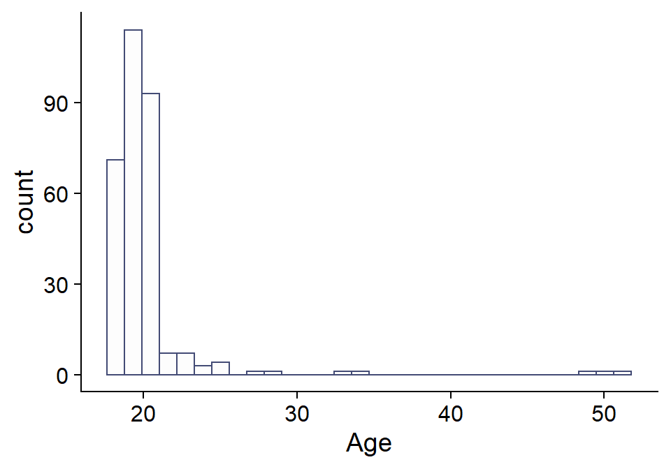

```r
library(cowplot)
gensex %>%
  ggplot(aes(x = Age)) +
  geom_histogram() +
  theme_cowplot()
`stat_bin()` using `bins = 30`. Pick better value with `binwidth`.
```

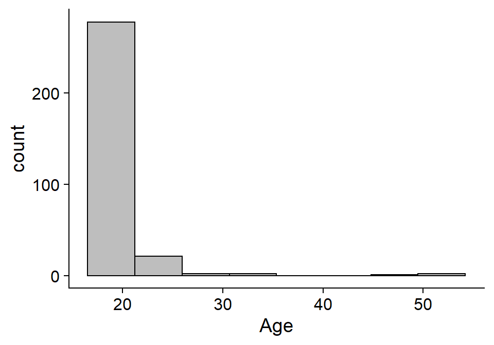

```r
library(cowplot)
gensex %>%
  ggplot(aes(x = Age)) +
  geom_histogram(bins = 8, color = "black", fill = "grey") +
  theme_cowplot()
```

That looks way better! The only thing left to do now is give our axes proper labels:

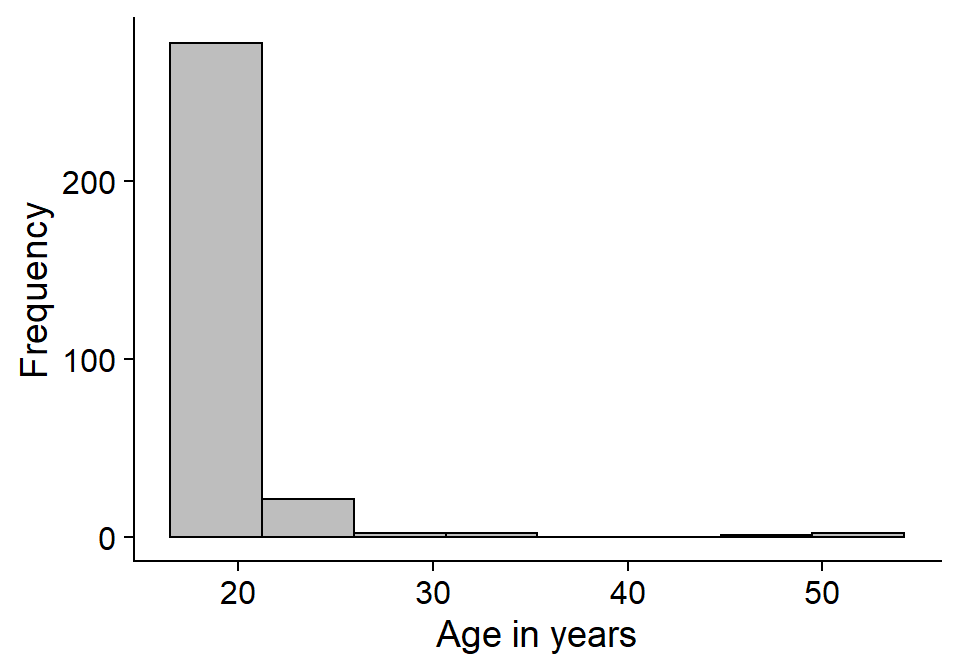

```r
library(cowplot)
gensex %>%
  ggplot(aes(x = Age)) +
  geom_histogram(bins = 8, color = "black", fill = "grey") +
  labs(x = "Age in years", y = "Frequency") +
  theme_cowplot()
```

There, that’s one neat plot!

OK, let’s see what we can do with our `Gender` variable.

Basically the only way of visualising a single categorical variable is using the barchart:

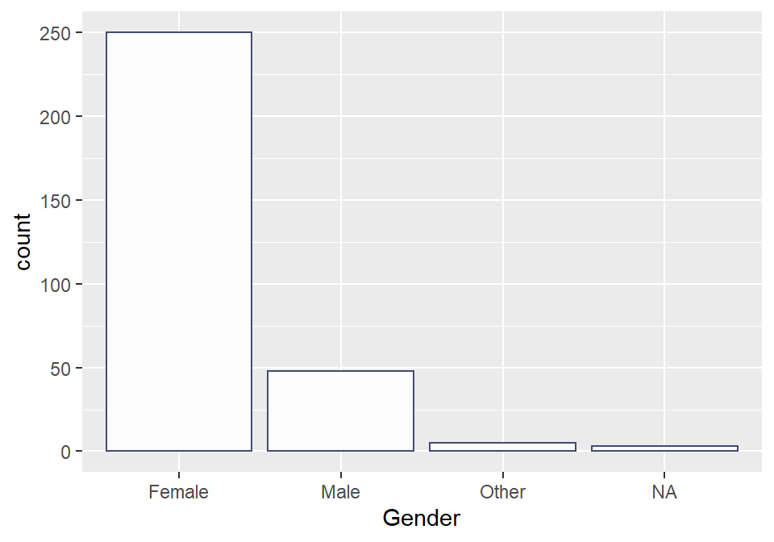

```r
gensex %>%
  ggplot(aes(x = Gender)) +
  geom_bar()
```

Again, we can customise the plot in several ways. Notice that the bars are ordered alphabetically and their labels are the same as the levels of our `Gender` variable:

```r
gensex %>%
  pull(Gender) %>%
  levels()
[1] "Female" "Male"   "Other"
```

Let’s tweak the appearance of our plot using what we already know:

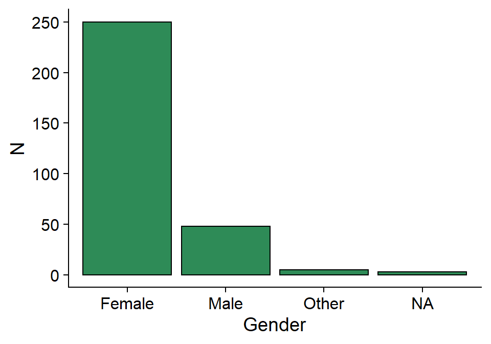

```r
gensex %>%
  ggplot(aes(x = Gender)) +
  geom_bar(color = "black", fill = "seagreen") +
  labs(x = "Gender", y = "N") +
  theme_cowplot()
```

I think this one is also rather nice!

If you really care about the small things and want to replace the `NA` with something more explicit, you can use the `fct_explicit_na()` function that turns `NA` into `(Missing)` by default (but this can be changed to whatever you want). Again, because we’re essentially changing the variable, the command needs to be inside `mutate()`:

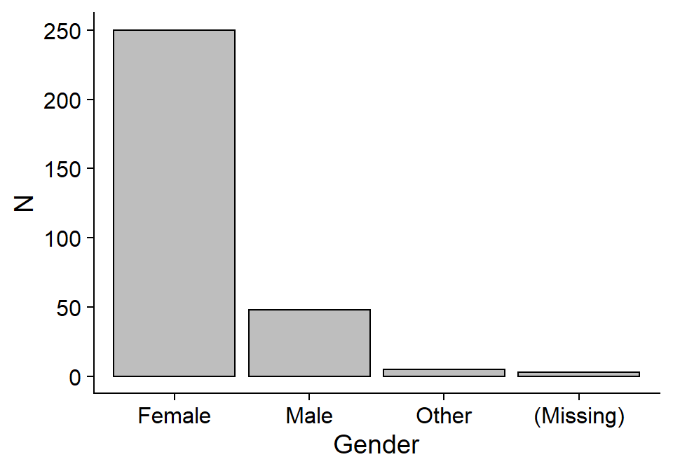

```r
gensex %>%
  mutate(Gender = fct_explicit_na(Gender)) %>%
  ggplot(aes(x = Gender)) +
  geom_bar(color = "black", fill = "grey") +
  labs(x = "Gender", y = "N") +
  theme_cowplot()
```

*Note* that the `mutate()` command comes before the data are pushed into `ggplot()`. That is because we aren’t really changing the plot itself but the `gensex` tibble. We are essentially telling `R` to temporarily modify the `Gender` variable in the tibble before it gets used for plotting.

Next, we can visualise the age breakdown by gender choice using boxplots. To do this, you need to map each of these variables onto one axis inside of the `aes()` function: The categorical variable belongs on the X axis and the continuous on the Y axis:

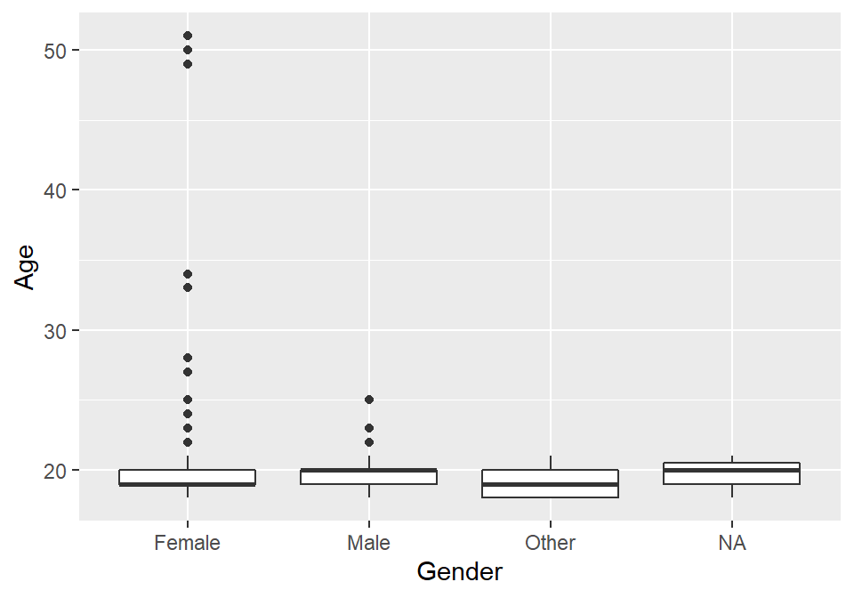

```r
gensex %>%
  ggplot(aes(x = Gender, y = Age)) +
  geom_boxplot()
```

We can re-use essentially all the commands from our previous plot to make this boxplot by group a little nicer.

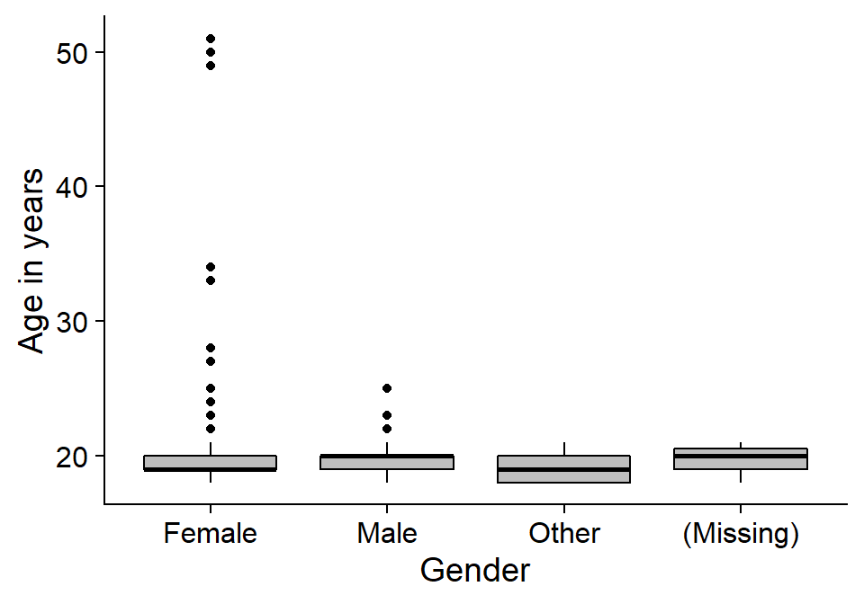

```r
gensex %>%
  mutate(Gender = fct_explicit_na(Gender)) %>%
  ggplot(aes(x = Gender, y = Age)) +
  geom_boxplot(color = "black", fill = "grey") +
  labs(x = "Gender", y = "Age in years") +
  theme_cowplot()
```

That’s it for descriptive visualisation. Let’s build up a more interesting plot that will show us something about the relationships between the main measured variables.

Suppose we are interested in knowing whether there is a relationship between participants’ self-ratings of masculinity and femininity. If these are inverses of each other as is sometimes claimed, the dots should be pretty much lined up: the more masculine you think you are, the less feminine you consider yourself. However, these dimensions may well not be opposites of one another. If that’s the case, it is possible for a person to feel both highly masculine and feminine at the same time. Let’s build a plot to find out.

Since both of these variables are continuous, a scatterplot is probably the best option. In `ggplot()`, we create scatterplots using `geom_point()`:

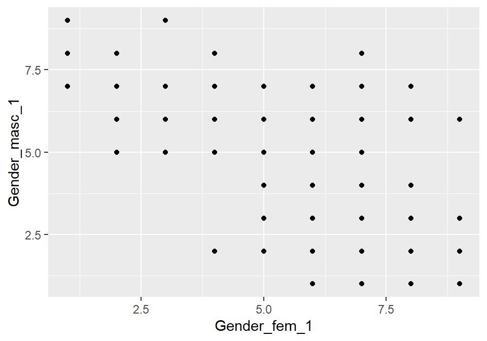

```r
gensex %>%
  ggplot(aes(x = Gender_fem_1, y = Gender_masc_1)) +
  geom_point()
```

OK, there is definitely a moderate-to-strong negative relationship between a person’s masculinity and femininity self-rating but it’s hardly perfect. Some people are relatively high on both of these dimensions!

The plot also looks like we only have a handful of observations because the points are drawn on top of each other. We can jitter them around to get a better reflection of our sample size. Now, jittering points makes the plot lie a little about the actual values people chose but the trade-off is that the sample size shows better.

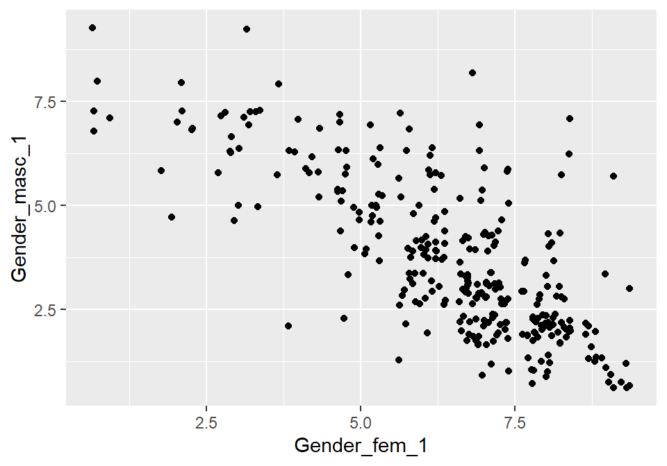

```r
gensex %>%
  ggplot(aes(x = Gender_fem_1, y = Gender_masc_1)) +
  geom_point(position = "jitter")
```

That’s better.

Now, let’s say we want to know if the relationship looks the same for each level of the `Gender` variable. We can choose to colour the points by gender. **Since we’re mapping a variable, we need to do this as an æsthetic using the `aes()` function**:

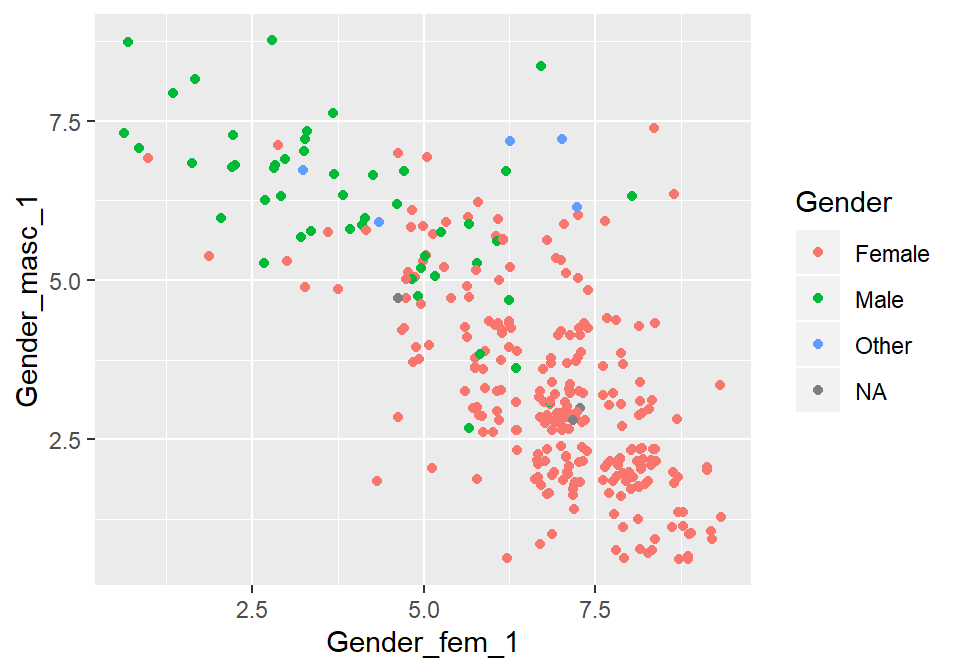

```r
gensex %>%
  ggplot(aes(x = Gender_fem_1, y = Gender_masc_1, colour = Gender)) +
  geom_point(position = "jitter")
```

Finally, we can change the look of the plot a little. Let’s make the points a little larger using the `size=` argument and ever so slightly transparent (`alpha=` goes from 0 to 1). Then add better axis labels and change the theme of the plot.

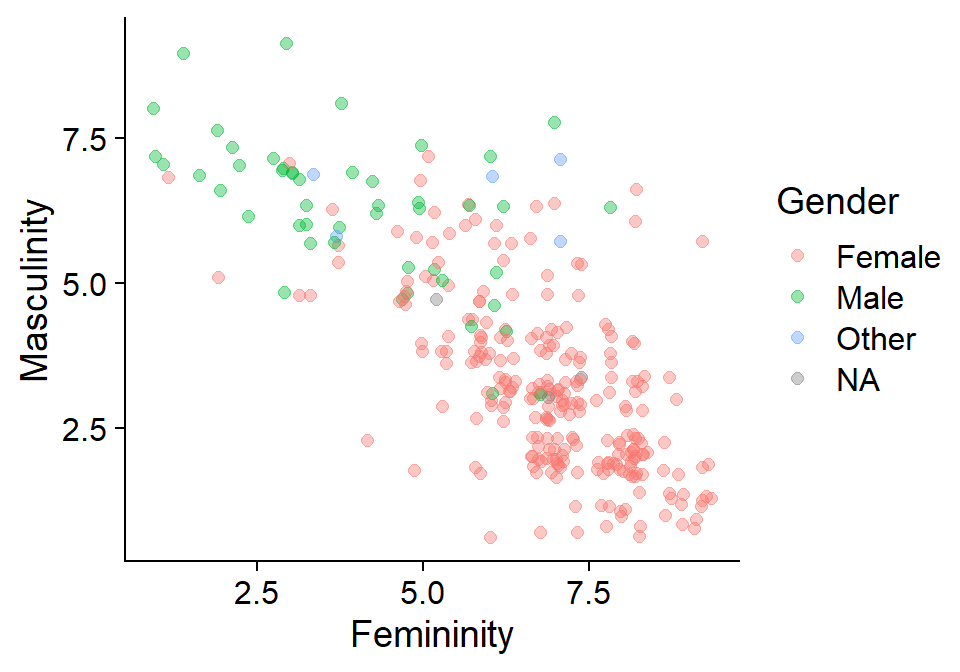

```r
gensex %>%
  ggplot(aes(x = Gender_fem_1, y = Gender_masc_1, colour = Gender)) +
  geom_point(position = "jitter", size = 2, alpha = .4) +
  labs(x = "Femininity", y = "Masculinity") +
  theme_cowplot()
```

That’s a nice one!

It’s interesting to see that different gender categories display different patterns. While participants who reported their gender as female seem to be roughly spread across the diagonal of the plot, those who reported their gender as male seem to be distributed more flatly in the top half of the plot. Unfortunately, we do not have enough data from participants in the “Other” category to make any observations.

Please bear in mind that we cannot really say for certain if these differences are statistically significant just by looking at the scatterplot. For that, we need to run some tests!

This is just about enough plotting for one day. If you’ve been typing along, save your script.

**Over to you!**

## Worksheet

In the remaining time you will practice visualising data with `ggplot()`. We will be using the same data from the [paper by Swiderska and Küster (2018)](https://journals.sagepub.com/doi/10.1177/0301006618809919) as we did last time.

### Task 1

First of all, if you haven’t finished last week’s tasks pick up where you left in the [week 3 practical worksheet](https://mivalek.github.io/adata/prac/prac_03_wkst.html#worksheet). There is a [version with solutions](https://mivalek.github.io/adata/prac/sol/prac_03_wkst_sol.html#worksheet) available now if you need help but when you use it, make sure you understand the code! There’s no point copy-pasting the solutions just for the sake of completing the tasks.

### Task 2

Download the “prac_04_visual.Rmd” file from Canvas and open it in RStudio. It is an expanded version of the one you were working on last week. Practice makes perfect…

Use the R Markdown file to complete the following tasks.

### Task 3

Complete the `packages`, `read-in`, `inspect`, and `descriptives` code chunks, as per last week’s tasks. You have done it before so it would be great if you could do the tasks without further prompting. If you need a little help, that’s OK. Just check out the worksheet for the individual tasks. If you must, you can even check the code you used last time but try not to copypaste it here. Rather, type it in manually to help develop coding habits.

### Task 4

Complete the code for the histogram of age, bar chart of gender and boxplot of age by gender in the `plots` chunk. They should look like this (feel free to choose the colours you like):

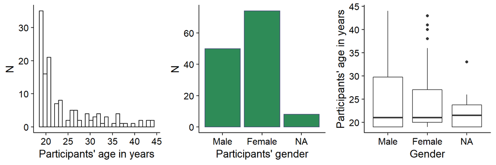

Since the plots are assigned to objects using the `<-` operator, they will not be shown when you run the code in the chunk. To see what they look like you need to either only run the part of the code to the right of the `<-` or run the chunk and then type the name of the object into the console.

### Task 5

Complete the code for the `pain_consc` plot so that it looks like this:

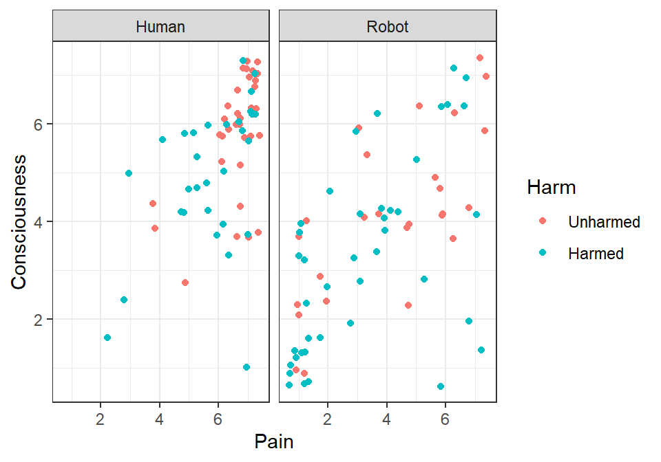

Notice how the `facet_wrap()` function is used to create two plots faceted by the `Humanness` variable.

### Task 6

Complete the **Write-up** section of the .Rmd file.

### Task 7

Edit the code in the `table_1` code chunk, giving it your tibble with age breakdown by gender, to create a nice formatted table in your document. Make sure the table show values to 2 decimal digits and to reference your table somewhere in the body text.

Table 1 *Descriptive statistics by categories of gender*

| Gender | *N* | % | *M*<sub>age</sub> | *SD*<sub>Age</sub> |
| --- | --- | --- | --- | --- |
| Male | 50 | 37.88 | 25.10 | 7.82 |
| Female | 74 | 56.06 | 24.05 | 5.96 |
| (Missing) | 8 | 6.06 | 22.75 | 4.86 |

### Task 8

Use the `fig_1` code chunk to print the grouped scatterplot. Notice how we specified the figure caption. All figures in a paper/report should have captions.

**Hint:** Just put the name of the object that contains the plot inside the chunk.

### Task 9

Inspect the scatterplot and think about the patterns you see. Talk to your classmate about what the relationships shown in the plot might be.

### Task 10

Use the `append_figs` code chunk to print the descriptive plots you made earlier in the Appendix.

Descriptive plots are rarely important enough to warrant space in the results section but they can be useful for the reader and so can be included in the Appendix/Supplementary materials.

### Task 11

Knit (generate) the final document from your R markdown file and rejoice in its beauty.

This week you learnt how to make pretty data visualisations and you added a Materials section to your write-up. Next time, we will review everything we’ve learned so far and practice the skills needed to prepare data for analysis and hypotheses testing, as you’ll do in your lab report. But, for now…

**Well done!**

## FAQ/Errors

Remember to check your `R` environment pane to see the changes applied to the objects (*e.g.,* data, tables, vectors, etc.) you are working with at every step. This makes it easier to notice any mistakes early on before they affect subsequent steps in your script.

*Note.* Check that you are working within the correct type of document. If you are working within a markdown file, you need to make sure all your code is within code chunks, not just freely floating within the body text. If you are working with an `R` script, ensure that the script only includes code, and if you have any comments/text in the file, they have to be preceded by a hash (`#`).

**RStudio will not load in the package using `library()` and gives me an error that says there is no such package.**

If a package does not exist, you simply have to install it on your computer using `install.packages("package_name")`. **This only needs to be done once** so do not put `install.packages()` commands in your `R` script/R Markdown documents. Once installed, you must load each package you want to use every time you open RStudio using the `library(package_name)` function. `R` scripts and R Markdown documents must include code to load all packages used within.

**RStudio can’t find the function I need to use for the tutorial (*e.g.,* `read_csv()` or `%>%`).**

If a certain function cannot be found, it means that the package including this function has not yet been loaded. If you load the required package, the function will become available.

**The change I made to an object is not being saved to it.**

To save the changes you have made to an object, remember to use the assignment operator `<-`. For example, simply typing `data %>% summary()` will give you the summary of the dataset, but will not save the results into any object. To save the output of this code, you can use an assignment operator: `data_summary <- data %>% summary()`. Make sure you don’t save summary objects over the data itself (*e.g.,* `data <- data %>% summary`) as that will overwrite the existing dataset!

**I am trying to use `read_csv()` to import the dataset but it is not working.**

To use the `read_csv()` function, you need to make sure the file path/hyperlink is between quotation marks (`"`) and that there is no period at the end of the path. For example:

- Bad: `read_csv(https://some/web/address/data.csv.)`
- Good: `read_csv("https://some/web/address/data.csv")`

**The tasks in the worksheet cannot be applied to the data I am working with.**

Double check to see if you are working with the correct data and note that the guided part of the worksheet often works with a different dataset than the one you are supposed to be working with in the worksheet.

**I ran the code and it seems to be working fine but I got a warning message.**

Warning messages are not necessarily indicative of a problem; they are simply `R`’s way of saying: “I did something and you should know about it.”

**Help! I have an error not listed here and I can’t work it out.**

Error messages in `R` are not always intuitive but try to read into the error message and figure out what the problem might be. If you still can’t work it out, there are plenty of ways you can get around it! You can:

- Type `?` before the function you are trying to use in the console and press `↵ Enter`. This will pull up the help file for the function which will have more information about the correct use and various examples (*e.g.,* `?mutate`).
- Copy and paste the error into you preferred web search engine (DuckDuck Go, Google, Bing…) and check the solutions online.
- Check the environment for hints about what might be going wrong.